# DATA2002 Assignment

- Show All Code
- Hide All Code
- View Source

Author

310215056

Published

September 10, 2023

## 1 Introduction

### 1.1 A Tale of Two Libraries

From the Law Library to the various Learning Hubs scattered throughout the University of Sydney, students have a variety of locations to study, work, read, or just kill time until their next class. However, two stand out among the bunch: the Fisher Library and the SciTech Library. The two towering titans of tomes provide a safe haven for students to expand their knowledge in their respective field. But do certain students prefer one library over another? If they do, are there other factors that are similar?

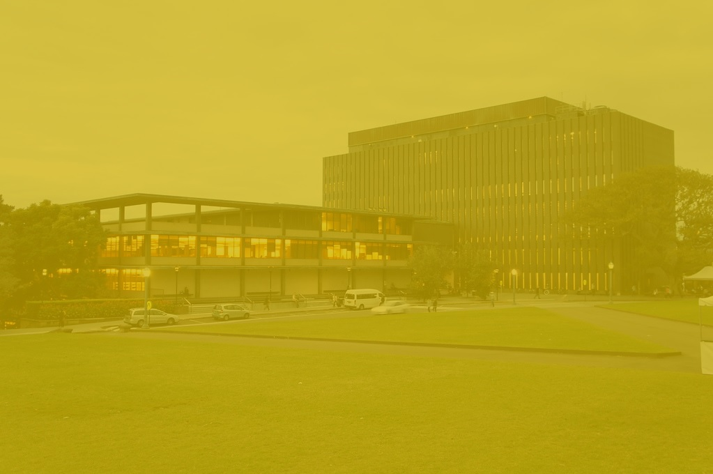

Fisher Library (Chen 2012)

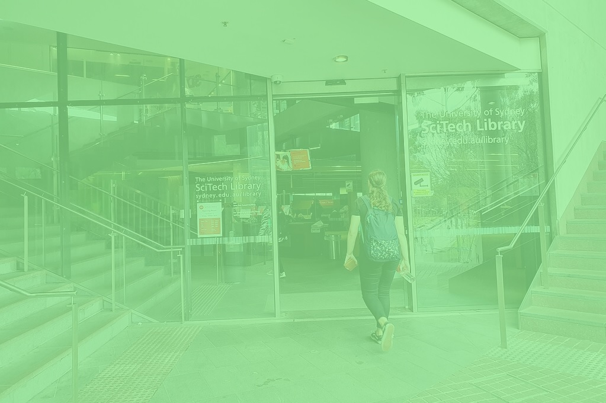

SciTech Library (Vakrieger 2019)

Figure 1: University of Sydney Libraries

The questionnaire can be utilised to determine the different habits of students that usually study at Fisher Library or at Scitech Library (Figure 1). By looking at students library preference in relation to what year they are in, how much time they spend on social media and what position of urinal they use in a empty bathroom, we can gain some insight into the types of students that use either library.

### 1.2 Questions

#### 1.2.1 Is this a random sample of DATA2X02 Students?

Due to the voluntary nature of the survey, there would be an element of self-selection bias that would become involved in the results. However, the influence of this bias on the observations would be quite minimal, and thus, we can consider this to be a random sample of DATA2x02 Students.

To truly have a random sample, a students could have been selected randomly to participate in the survey. This would pose issues with both sample size and could have ethical challenges. With the cohort being the size it is, a randomly selected group may not be able to have a large enough sample size. By selecting some students and not others, there could be a ethical issue with only some students being involved with data that all students will later use.

The use of a voluntary survey is not ideal in creating a random sample, but for the sake of this survey, the sample can be considered random.

#### 1.2.2 What are the potential biases? Which variables are most likely to be subjected to this bias?

There is the possibility of many potential biases involved in this study, such as self-selection bias, response bias and recall bias.

As mentioned above, there is an element of self-selection bias that would be involved in this study. Due to it being voluntary, there is the possibility that not all students completed the survey and only those that made the choice to are involved in the data. This could potentially influence any questions in the survey.

Another bias that would be more prevalent is response bias. There would be two potential outcomes of this sort of bias: students not answering the question at all or answering in an untruthful way. As questions are allowed to be skipped in the survey, there are many `NA` values in the data. This has come from every question. Students may also not answer the question truthfully, whether it be consciously or unconsciously. Examples of questions that would be influenced by this bias are:

- How many hours a week do you spend studying?
- Do you submit assignments on time?
- Have you ever used R before starting DATA2x02?
- How many days in a week you normally consume sweets/chocolates/sugary drinks? (Exclude Diet/Sugar Free Drinks & sweets)?
- On average, how many hours each week do you spend exercising?
- What kind of role (active or passive) do you think you are when working as part of a team?

These questions may be answered untruthfully as the student wants to appear *better* to the teaching staff, their fellow students or even feel guilty about putting a lower/higher than average answer.

Recall bias may also be prevalent in this study. The students may not be able to remember exact answers to certain questions, such as:

- How many days do you go between haircuts (on average)?
- What is your WAM?

Unless they can remember their exact answer, students may put down an answer that seems right or not answer it at all.

#### 1.2.3 Which questions needed improvement to generate useful data (e.g. in terms of the way the question was phrased or response validation)?

The structure of a lot of the questions in this survey could be improved. Some questions are posed correctly but require some validations in the answered received by participants and others need to be rewritten or adjusted to clarify what response is need. If the question posed required a numerical response, this should be validated at the time of entry.

- How much sleep do you get (on avg, per day)?
  - This question should be posed to give the response in hours
  - Validation should be performed to ensure the response is numeric, greater than 0 and less than 24
- What is your gender?
  - This question should use a drop down or multiple choice selection to correctly classify data
  - The options should be *Male*, *Female*, *Non-Binary* and *Decline to answer*
  - An option for *Other* responses should be included in case participants do not fit into the above categories, although most will
- How many units are you enrolled in this semester?
  - This question should use a drop down of 1 to 6 units to ensure the responses fit into correct categories
  - Responses were made using credit points, which could be changed into units, however some units are worth different amounts of credit points
  - The university has a policy of 24 credit points (4-5 units) per semester, with special applications allowing up to 30 credit points
- Would you prefer to study at Fisher Library or SciTech Library?
  - The *Other* option should be removed from this question as the question poses a binary response.
- What brand is your laptop?
  - It would be best to include common choices for laptop brands (Apple, HP, Lenovo, etc) as multiple choice options to ensure consistency of response.
  - There can be an *Other* option if the brand is uncommon
- How tall are you?
  - This question needs to include the units for the response, be that cm, m or feet/inches
- How many days in a week you normally consume sweets/chocolates/sugary drinks? (Exclude Diet/Sugar Free Drinks & sweets)?
  - This question is posed in a confusing way and could be misinterpreted
  - It would be better posed as *How many days in a week you normally consume non-diet/sugar-free sweets/chocolates/sugary drinks?
- Do you like pineapple on pizza?
  - The *Other* option should be removed and possibly replaced with a *Sometimes* multiple choice option as this is most likely the only other response to this question
- What is your shoe size?
  - There needs to be clarification on the size scheme to respond with (US, UK, EU, etc)
- Do you pay rent?
  - Like the library preference question, the *Other* option should be removed as this is a binary response
- What is your post code?
  - The response should be from a dropdown box listing all valid postcodes for NSW and possibly an *Out of state* option

## 2 Data Importing and cleaning

The data was gathered from a questionnaire submitted for DATA2x02 students to fill out. From this data we have selected some questions to focus on. These questions will require some cleaning and answer validation.

```r
library(tidyverse)
library(knitr)
library(ggplot2)
library(ggpubr)
library(cowplot)

write_bib(c(.packages()), "packagereferences.bib")
x = readr::read_csv("DATA2x02 survey (2023) (Responses) - Form responses 1.csv")
```

This report will use *R* (R Core Team 2023) for calculations, utilising the *tidyverse* (Wickham 2023) package for data transformation. The *ggplot2* (Wickham 2016), *ggpubr* (Kassambara 2023) and *cowplot* (Wilke 2020) packages are all used for plotting and the *knitr* (Xie 2015) package is used to format output in the report.

From the *Data importing and cleaning guide* (Tarr 2023), we are provided with much simpler names for the columns in the raw data.

```r
# From Data importing and cleaning guide
new_names = c("timestamp","n_units","task_approach","age",
              "life","fass_unit","fass_major","novel",
              "library","private_health","sugar_days","rent",
              "post_code","haircut_days","laptop_brand",
              "urinal_position","stall_position","n_weetbix","food_budget",
              "pineapple","living_arrangements","height","uni_travel_method",
              "feel_anxious","study_hrs","work","social_media",
              "gender","sleep_time","diet","random_number",
              "steak_preference","dominant_hand","normal_advanced","exercise_hrs",
              "employment_hrs","on_time","used_r_before","team_role",
              "social_media_hrs","uni_year","sport","wam","shoe_size")
# overwrite the old names with the new names:
colnames(x) = new_names
```

The columns that we will be focusing on are `library`, `urinal_position`, `social_media_hrs` and `uni_year`. We can move these into a new dataframe to work on cleaning them.

```r
qdat = tibble(x$library, x$urinal_position, x$social_media_hrs, x$uni_year)
colnames(qdat) = c("library", "urinal_position", "social_media_hrs", "uni_year")
```

### 2.1 `library` column

Looking at the `library` column, there are 25 different entries in the column. Considering there should only be 2 choices (Fisher or SciTech), we need to treat any other entries as invalid.

```r
validlibs = c("Fisher", "SciTech")
qdat = qdat %>%
  mutate(library = case_when(
    library %in% validlibs ~ library,
    TRUE ~ NA_character_
  ))
levels(qdat$library) <- c("Fisher", "SciTech")
colourpalette <- c("gold3", "lightgreen")
names(colourpalette) <- levels(qdat$library)
```

Now there are only 3 distinct entries in the column: Fisher, SciTech, NA. There are still 270 entries for the column, more than enough to perform analysis.

### 2.2 `urinal_position` column

This question in the original questionnaire did not allow for any options other than *A*, *B*, or *C*, all the entries in this column will either be valid or `NA`. Thus, we do not need to do any cleaning. There are 281 valid entries in this column.

### 2.3 `social_media_hrs` column

Upon initial inspection of the values in this column, there appear to be some outlying values. Any values over 24 can automatically be discarded as the question was about social media usage per day. It would be safe to assume that any social media usage over 8 hours per day would be invalid. Given that the participants are university students, having enough time for 8 hours of social media every day (56 hours per week, more than full time work) seems extremely unlikely.

```r
qdat = qdat %>%
  mutate(social_media_hrs = case_when(
    social_media_hrs < 8 ~ social_media_hrs,
    TRUE ~ NA
  ))
```

After filtering out inappropriate entries, there are still 275 valid entries in this column.

### 2.4 `uni_year` column

```r
qdat$uni_year = factor(qdat$uni_year, levels = c("First year",
                                                 "Second year",
                                                 "Third year",
                                                 "Fourth year",
                                                 "Fifth or higher year"
                                                 ))
```

## 3 Results

### 3.1 Is the preference for studying at Fisher Library or SciTech independent of what year a student is in?

There are many places to study at the University of Sydney, but the two most popular by far are the Fisher Library and the SciTech library. By classifying students by what year they are in in university, we can determine if the student’s choice of library is independent of the year the student is in. Figure 2 shows the proportion of students per year that prefer to study at either Fisher or SciTech Libraries

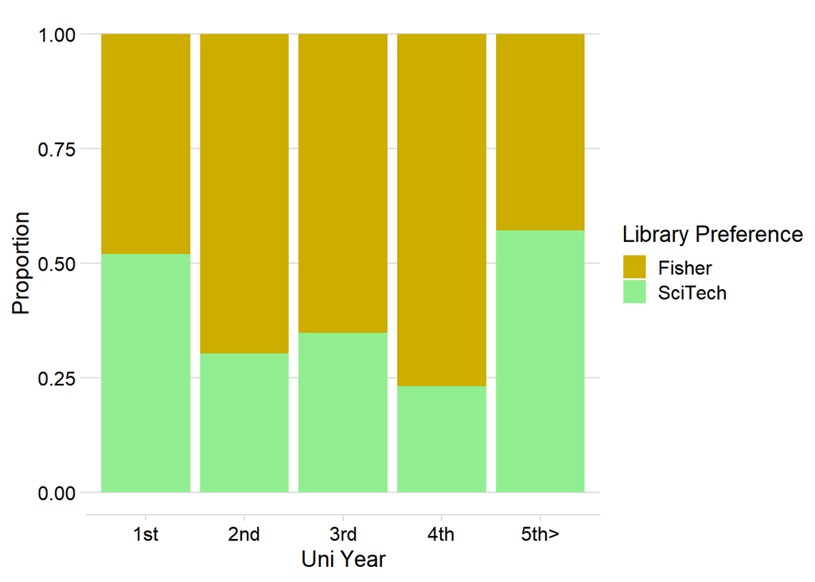

Figure 2: Proportion of Library Preference for each year at University

```r
libyeartab = table(qdat$library, qdat$uni_year)
libyeartab_df = as.data.frame(libyeartab)
colnames(libyeartab_df) = c("Library", "Uni Year", "Count")

libyeartab_df %>%  ggplot(aes(x = `Uni Year`, y= Count, fill = Library)) +
  geom_bar(stat = "identity", position = "fill") +
  labs(x = "Uni Year", y = "Proportion", fill = "Library Preference") +
  scale_x_discrete(labels = c("1st", "2nd", "3rd", "4th", "5th>")) +
  scale_fill_manual(values = colourpalette) +
  theme_minimal_hgrid()
```

There does not appear to be an equal proportion of library choice for each year, however, to formally test the independence of these variables, we can use a Chi-squared test for independence with Monte Carlo simulation with a level of significance of 5% ($\alpha = 0.05$).

```r
# chi-squared test with monte carlo simulation (10000 resamples)
set.seed(123)
res1 = chisq.test(libyeartab, simulate.p.value = TRUE, B = 10000)
kable(round(res1$expected, 3))
```

Table 1: Table of expected values for library preference across university years

|  | First year | Second year | Third year | Fourth year | Fifth or higher year |
| --- | --- | --- | --- | --- | --- |
| Fisher | 16.636 | 116.45 | 32.606 | 8.651 | 4.658 |
| SciTech | 8.364 | 58.55 | 16.394 | 4.349 | 2.342 |

By using a Monte Carlo simulation, we can eliminate the problems that we would usually have with small expected values from this data. As you can see in Table 1, there are several values where $e_{ij} \leq 5$, which would create issues if we were to use a standard chi-squared test for independence. We will use 10,000 resamples to provide an effective simulation for the results.

Let $i$ indicate the Library preference (1 for Fisher and 2 for SciTech) and $j$ indicate the university year. $i\bullet$ indicates the total for the $i^{th}$ row and $\bullet j$ indicate the total for the $j^{th}$ column.

#### 3.1.1 Workflow

1. **Hypothesis:** $H_0:$ $p_{ij} = p_{i\bullet}p_{\bullet j}$, $i = 1,2$, $j=1,2,3,4,5$ vs $H_1:$ Not all equalities hold.
2. **Assumptions:** independent observations
3. **Test statistic:** $T = \sum\limits_{i=1}^{5} \sum\limits_{j=1}^{2}\frac{(Y_{ij}-e_{ij})^2}{e_{ij}}$. Under $H_0$, $T\sim \chi^2_4$ approx.
4. **Observed test statistic:** $t_o = \sum\limits_{i=1}^{5} \sum\limits_{j=1}^{2}\frac{(y_{ij}-y_{i\bullet}y_{\bullet j}/n)^2}{y_{i\bullet}y_{\bullet j}/n}= 7.078$
5. **p-value:**$P(T\geq t_0) = P(\chi^2_4 \geq t_0)=0.123$
6. **Decision:** As the p-value calculated above (0.123) is greater than 0.05, we do not reject the null hypothesis. This means that there is not significant evidence that there is a relationship between the year a university student is in and what library they prefer to study in.

### 3.2 Do students who study at Fisher Library prefer a different urinal to those who study at SciTech Library?

With the students studying in different locations, there may be differences in which urinal they would be inclined to use in the location they’re studying at. While the survey didn’t specify that the urinal was in the bathroom of the library they are studying in, we can test if there is a possibility that the two variables are related. Figure 3 shows the proportions for library preference, broken down into which urinal position they would theoretically choose. An interesting note to make: the survey was open to a diverse range of students and, as such, there would be those who do not have any experience using a urinal. The survey did specify those to imagine what it would be like.

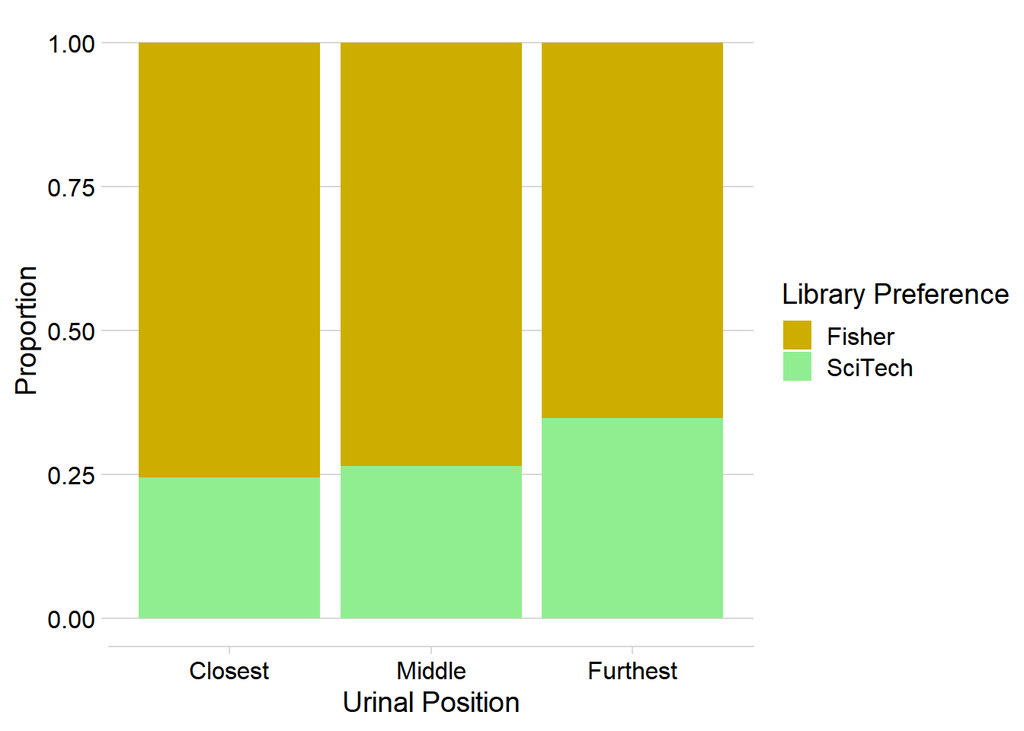

Figure 3: Proportion of library preference for each urinal position

```r
# Create a data frame to plot
urinallibtab = table(qdat$urinal_position, qdat$library)
urinallibtab_df = as.data.frame(urinallibtab)
colnames(urinallibtab_df) = c("Urinal Position", "Library", "Count")

# Plot!
urinallibtab_df %>%  ggplot(aes(x = `Urinal Position`, y= Count, fill = Library)) +
  geom_bar(stat = "identity", position = "fill") +
  labs(x = "Urinal Position", y = "Proportion", fill = "Library Preference") +
  scale_x_discrete(labels = c("Closest", "Middle", "Furthest")) +
  scale_fill_manual(values = colourpalette) +
  theme_minimal_hgrid()
```

The plot shows that the proportion of students who study at Fisher library is almost equal for those who would chose the closest or middle urinal, while the proportion is slightly less for those that choose the furthest urinal. This could suggest that there is a correlation between th library preference and whether the student picks the furthest urinal or not. We can reshape our data to combine the closest and middle positions into one set.

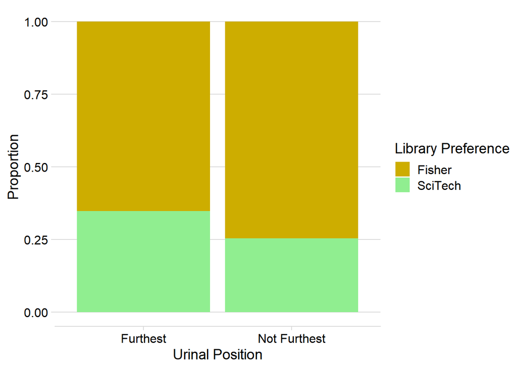

Figure 4: Proportion of library preference for either furthest urinal or not furthest urinal

```r
# Perform chi-squared test before combining variables
res2.1 = chisq.test(urinallibtab, correct = TRUE)

#Combine variables and remove NA values
urinals_to_combine = c("A: Closest to the entrance", "B: Middle")
qdaturinal = drop_na(tibble(qdat$urinal_position, qdat$library))
colnames(qdaturinal) = c("urinal_position", "library")
qdaturinal = qdaturinal %>%
  mutate(urinal_position = case_when(
    urinal_position %in% urinals_to_combine ~ urinal_position,
    TRUE ~ "Furthest"
  )) %>%
  mutate(urinal_position = case_when(
    urinal_position == "Furthest" ~ urinal_position,
    TRUE ~ "Not Furthest"
  ))

# Turn the table into a dataframe to plot
urinallibtab = table(qdaturinal$urinal_position, qdaturinal$library)
urinallibtab_df = as.data.frame(urinallibtab)
colnames(urinallibtab_df) = c("Urinal Position", "Library", "Count")

# Plot!
urinallibtab_df %>%  ggplot(aes(x = `Urinal Position`, y= Count, fill = Library)) +
  geom_bar(stat = "identity", position = "fill") +
  labs(x = "Urinal Position", y = "Proportion", fill = "Library Preference") +
  scale_x_discrete(labels = c("Furthest", "Not Furthest")) +
  scale_fill_manual(values = colourpalette) +
  theme_minimal_hgrid()
```

Figure 4 shows the proportions given only 2 urinal categories. We can see that there is a difference in proportions, but we will formally test the 2 variables independence to see if there is evidence of a significant difference. To do so, we will perform a Chi-squared test for independence using Yates’ Continuity Correction to improve the accuracy of the result, as the counts in each cell of the table are relatively small (as can be seen in Table 2). We will use a level of significance of 5% for this test ($\alpha = 0.05$)

```r
kable(urinallibtab)
```

Table 2: Table of observed counts for library preference and urinal position choice

|  | Fisher | SciTech |
| --- | --- | --- |
| Furthest | 111 | 59 |
| Not Furthest | 59 | 20 |

```r
# chi-squared test with yates' continuity correction
res2.2 = chisq.test(urinallibtab, correct = TRUE)
```

Let $i$ indicate the Library preference (1 for Fisher and 2 for SciTech) and $j$ indicate the urinal position (1 for Furthest and 2 for Not Furthest). $i\bullet$ indicates the total for the $i^{th}$ row and $\bullet j$ indicate the total for the $j^{th}$ column.

#### 3.2.1 Workflow

1. **Hypothesis:** $H_0:$ $p_{ij} = p_{i\bullet}p_{\bullet j}$, $i = 1,2$, $j=1,2$ vs $H_1:$ Not all equalities hold.
2. **Assumptions:** independent observations and $e_{ij} = y_{i\bullet}y_{\bullet j}/n \geq 5$
3. **Test statistic:** $T = \sum\limits_{i=1}^{2} \sum\limits_{j=1}^{2}\frac{(Y_{ij}-e_{ij})^2}{e_{ij}}$. Under $H_0$, $T\sim \chi^2_1$ approx.
4. **Observed test statistic:** $t_o = \sum\limits_{i=1}^{2} \sum\limits_{j=1}^{2}\frac{(y_{ij}-y_{i\bullet}y_{\bullet j}/n)^2}{y_{i\bullet}y_{\bullet j}/n}= 1.783$
5. **p-value:** $P(T \geq t_0) = P(\chi^2_1 \geq 1.783) = 0.182$
6. **Decision:** We do not reject the null hypothesis as the p-value is greater than 0.05. This suggests that there is not significant evidence that a students choice of urinal and library preference is related to each other.

### 3.3 Is the average social media usage per day different for students that study at Fisher and SciTech Libraries?

While studying at either library, one environment may be more conducive to students becoming bored or distracted and spending more time on social media. We can classify students by their preference of library and look at the mean social media usage hours for each library. Table 3 shows a summary of the number of observations, the mean and the standard deviation for the student’s social media usage (in hours).

```r
summtable = qdat %>%
  select(social_media_hrs, library) %>%
  group_by(library)  %>%
  drop_na() %>%
  summarise(n = n(),
            Mean = mean(social_media_hrs) %>% round(2),
            SD = sd(social_media_hrs) %>% round(2)
            )

fmean = summtable$Mean[summtable$library == "Fisher"]
smean = summtable$Mean[summtable$library == "SciTech"]
fcount = summtable$n[summtable$library == "Fisher"]
scount = summtable$n[summtable$library == "SciTech"]
eqsigma = (summtable$SD[summtable$library == "Fisher"] +
  summtable$SD[summtable$library == "SciTech"])/2

kable(summtable, col.names = c("Library", "n", "Mean", "SD"))
```

Table 3: Summary table of social media usage for each Library

| Library | n | Mean | SD |
| --- | --- | --- | --- |
| Fisher | 161 | 3.09 | 1.66 |
| SciTech | 82 | 2.88 | 1.48 |

From this table, we can see that the means are similar and the variance is close to equal. However, we want to formally test this and thus will use a Two-Sample $t$-test. Seeing as the variance of samples are so close, we can assume that the two variances are the same. When using a $t$-test, there is an assumption that the samples are normally distributed and independent of one another. Independence can be assumed for these observations as student’s preference for library will not influence another student’s.

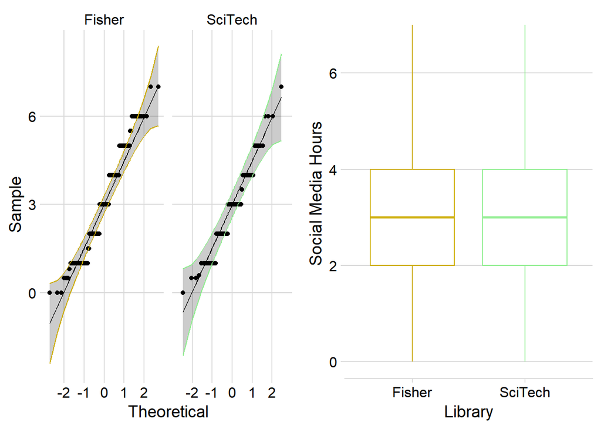

Figure 5: QQ Plots for social media usage for both Libraries and corresponding boxplots

```r
bp <- ggplot(
  drop_na(qdat), aes(x = library, y = social_media_hrs, colour = library)) +
  geom_boxplot() +
  scale_colour_manual(values = colourpalette) +
  labs(x = "Library", y = "Social Media Hours") +
  theme_minimal_hgrid() +
  theme(legend.position = "none")

qq <- ggqqplot(
  drop_na(qdat), x = "social_media_hrs", facet.by = "library") +
  aes(color = library, point_color = library, ) +
  scale_color_manual(values = colourpalette) +
  scale_fill_manual(values = colourpalette) +
  theme_minimal_grid() +
  theme(legend.position = "none")

plot_grid(qq, bp, ncol = 2)
```

Figure 5 shows quantile-quantile plots and boxplots for both libraries. The SciTech quantile-quantile plot very clearly shows that the observations are normally distributed. The Fisher plot has slight skewing at the tails, it is not enough to reject the assumption of the observations being normally distributed.The boxplots for both libraries provide more evidence that the variance for each set is roughly equal.

```r
res3 = t.test(
  filter(tibble(qdat$social_media_hrs), qdat$library == "Fisher"),
  filter(tibble(qdat$social_media_hrs), qdat$library == "SciTech"),
  alternative = "two.sided",
  var.equal=TRUE
  )
```

Let $X_i$ be the estimated social media usage for the $i^{th}$ student who studies at Fisher Library and $Y_j$ be the estimated social media usage for the $j^{th}$ student who studies at SciTech Library. Let $\mu_f$ and $\mu_s$ be the population mean for students who study at Fisher Library and SciTech Library respectively. $n_x$ and $n_y$ are 161 and 82 respectively.

#### 3.3.1 Workflow

1. **Hypothesis:** $H_O: \mu_f = \mu_s$ vs $H_1: \mu_f \neq \mu_s$
2. **Assumptions:** $X_1,...,X_{n_x}$ are *iid* $\mathcal{N}(\mu_f,\sigma^2)$, $Y_1,...Y_{n_y}$ are *iid* $\mathcal{N}(\mu_s, \sigma^2)$ and $X_i$’s are independent of $Y_i$’s.
3. **Test statistic:** $T = \frac{\bar{X}-\bar{Y}}{S_p \sqrt{\frac{1}{n_x}+\frac{1}{n_y}}}$ Under $H_0$, $T \sim t_{n_x+n_y-2}$
4. **Observed test statistic:** $t_0 = \frac{3.09 - 2.88}{1.57\sqrt{\frac{1}{161}+\frac{1}{82}}} = 0.977$
5. **p-value:** $2P(t_{241} \geq |0.977|) = 0.329$
6. **Decision:** Large p-value so the data is consistent with $H_0$. There does not appear to be evidence that the average daily social media usage is different in student who prefer to study at Fisher Library or SciTech Library.

## 4 Conclusion

These tests performed only focus on 3 different factors in regards to a students preference of study library. While each test did not provide evidence that the library preference is related to any of the 3 variables (university year, average daily social media use or urinal position choice), there could be some factors that are influenced by this choice.

If the population for this study was to be expanded to include students in other subjects or faculties (not just DATA2x02), a greater range of data may be able to provide some insights into these related variables.

## References

Chen, Kitty. 2012. “Fisher Library, USYD.” https://www.flickr.com/photos/kitty0217/7319963976.

Kassambara, Alboukadel. 2023. *Ggpubr: Ggplot2 Based Publication Ready Plots*. https://rpkgs.datanovia.com/ggpubr/.

R Core Team. 2023. *R: A Language and Environment for Statistical Computing*. Vienna, Austria: R Foundation for Statistical Computing. https://www.R-project.org/.

Tarr, Garth. 2023. “Data Importing and Cleaning Guide.” https://pages.github.sydney.edu.au/DATA2002/2023/assignment/assignment_data.html.

Vakrieger. 2019. “Entrance of University of Sydney’s SciTech Library.” https://commons.wikimedia.org/wiki/File:SciTech_Library_Entrance_AUG2019.jpg.

Wickham, Hadley. 2016. *Ggplot2: Elegant Graphics for Data Analysis*. Springer-Verlag New York. https://ggplot2.tidyverse.org.

———. 2023. *Tidyverse: Easily Install and Load the Tidyverse*. https://CRAN.R-project.org/package=tidyverse.

Wilke, Claus O. 2020. *Cowplot: Streamlined Plot Theme and Plot Annotations for Ggplot2*. https://wilkelab.org/cowplot/.

Xie, Yihui. 2015. *Dynamic Documents with R and Knitr*. 2nd ed. Boca Raton, Florida: Chapman; Hall/CRC. https://yihui.org/knitr/.